# Calculating Walking and cycling trips impedance function- 2015

```r
broom::glance(MASS::fitdistr(w_307_2015$DURATION%>% unlist() %>% as.numeric(),"exponential"))
```

| logLik | AIC | BIC | nobs |
| --- | --- | --- | --- |
| -172.5814 | 347.1628 | 349.013 | 47 |

So, lognormal has largest logLik and the smallest AIC and BIC. we will pick lognormal function for walking trips in 2015!(307)

```r
walking_30715_lnorm <- lnorm_w307_2015_
w_307_2015 <- w_307_2015 %>%
 mutate(f_307 = dlnorm(DURATION, walking_30715_lnorm$estimate["meanlog"], walking_30715_lnorm$estimate["sdlog"]))
summary(w_307_2015$f_307)
```

```
     Min.   1st Qu.    Median      Mean   3rd Qu.      Max.
0.0006845 0.0294756 0.0615529 0.0525671 0.0763756 0.0763756
```

###Destination : Restaurant, bar or club (309) using a skew vs. kurtois graph to descriptive statistics of data

```r
# creating a skew vs. kurtois graph for walking 2015

# Filter the data based on the "destination" column
 w_309_2015 <- walking_2015 %>%
  filter(destination == "309")

descdist(w_309_2015$DURATION %>% unlist() %>% as.numeric(), discrete=FALSE, boot=500)
```

[output not shown]

```r
# Based on the skew vs. kurtois graph the best distribution

#Calculating gamma distribution

gamma_w309_2015_ <- fitdistrplus::fitdist(data=w_309_2015$DURATION%>% unlist() %>% as.numeric(), "gamma", method="mle", optim.method="Nelder-Mead", weights = round(w_309_2015$WGHT_EPI))
fit_dgamma_30915 <- data.frame(f = dgamma(w_309_2015$DURATION, shape = gamma_w309_2015_$estimate[1], rate = gamma_w309_2015_$estimate[2]), x = w_309_2015$DURATION, type = "Gamma")

summary(gamma_w309_2015_)
```

```
Fitting of the distribution ' gamma ' by maximum likelihood
Parameters :
```

|  | estimate | Std. Error |
| --- | --- | --- |
| shape | 2.2613632 | 0.0041975838 |
| rate | 0.1593937 | 0.0003311185 |

```
Loglikelihood:  -1777689   AIC:  3555383   BIC:  3555390
Correlation matrix:
          shape      rate
shape 1.0000000 0.8934871
rate  0.8934871 1.0000000
```

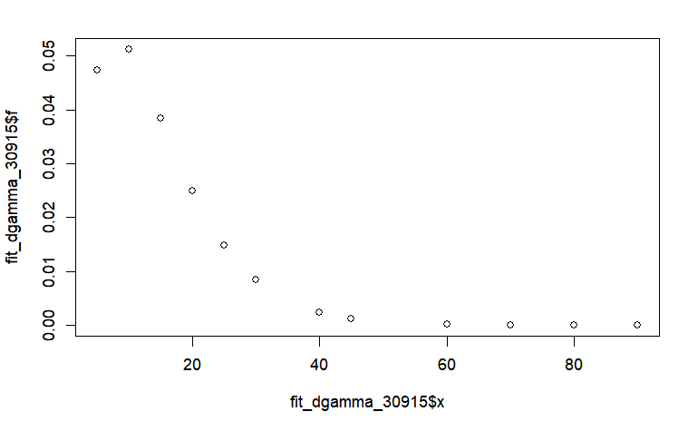

```r
plot(x= fit_dgamma_30915$x, y=fit_dgamma_30915$f)
```

```r
#Calculating exponential distribution
exp_w309_2015_ <- fitdistrplus::fitdist(data=w_309_2015$DURATION%>% unlist() %>% as.numeric(), "exp", method="mle", optim.method="Nelder-Mead", weights = round(w_309_2015$WGHT_EPI))
summary(exp_w309_2015_)
```

```
Fitting of the distribution ' exp ' by maximum likelihood
Parameters :
```

|  | estimate | Std. Error |
| --- | --- | --- |
| rate | 0.07050435 | 9.889522e-05 |

```
Loglikelihood:  -1855511   AIC:  3711023   BIC:  3711027
```

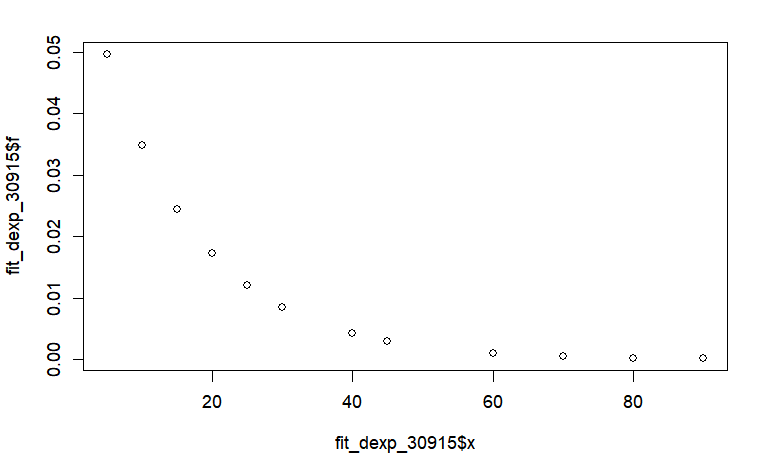

```r
fit_dexp_30915 <- data.frame(f = dexp(w_309_2015$DURATION, rate = exp_w309_2015_$estimate[1]),
                       x = w_309_2015$DURATION, type = "exp")

plot(x = fit_dexp_30915$x, y = fit_dexp_30915$f)
```

Now let’s compare these models AIC and BIC to see which fits the walk data best:

```r
#comparing these models AIC and BIC to see which fits the walk data best:
broom::glance(MASS::fitdistr(w_309_2015$DURATION%>% unlist() %>% as.numeric(),"gamma"))
```

| logLik | AIC | BIC | nobs |
| --- | --- | --- | --- |
| -884.4337 | 1772.867 | 1779.91 | 250 |

```r
broom::glance(MASS::fitdistr(w_309_2015$DURATION%>% unlist() %>% as.numeric(),"exponential"))
```

| logLik | AIC | BIC | nobs |
| --- | --- | --- | --- |
| -921.2807 | 1844.561 | 1848.083 | 250 |

So, gamma has largest logLik and the smallest AIC and BIC. we will pick gamma function for walking trips in 2015!(309)

```r
walking_30915_gamma <- gamma_w309_2015_
w_309_2015 <- w_309_2015 %>%
 mutate(f_309 = dgamma(DURATION, walking_30915_gamma$estimate["shape"], walking_30915_gamma$estimate["rate"]))
summary(w_309_2015$f_309)
```

```
     Min.   1st Qu.    Median      Mean   3rd Qu.      Max.
2.370e-06 3.842e-02 4.731e-02 4.059e-02 5.112e-02 5.112e-02
```

###Destination : Place of worship (310) using a skew vs. kurtois graph to descriptive statistics of data

```
summary statistics
------
min:  5   max:  45
median:  15
mean:  16.25
estimated sd:  9.810708
estimated skewness:  1.166855
estimated kurtosis:  4.25313
```

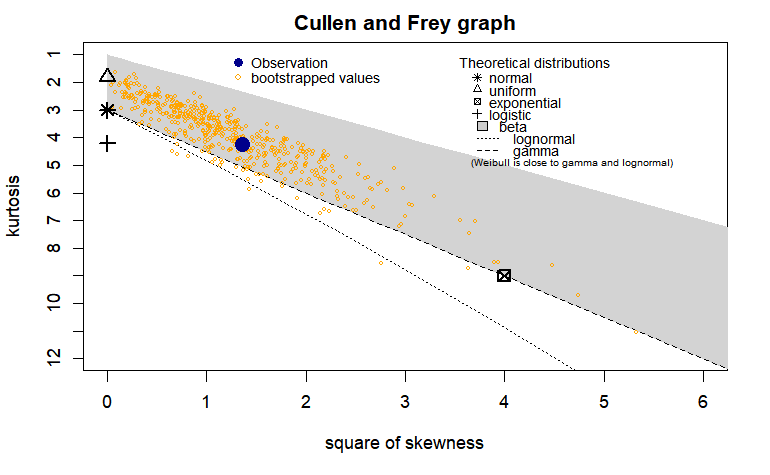

```r
# creating a skew vs. kurtois graph for walking 2015

# Filter the data based on the "destination" column
 w_310_2015 <- walking_2015 %>%
  filter(destination == "310")

descdist(w_310_2015$DURATION %>% unlist() %>% as.numeric(), discrete=FALSE, boot=500)
```

As shown in the Cullen and Frey graph, we see that gamma, normal, weibull, lognormal and exponential will likely be the best fit according to the graph above. Then we compare these models to find the best model.

```r
# Based on the skew vs. kurtois graph the best distribution

#Calculating gamma distribution

gamma_w310_2015_ <- fitdistrplus::fitdist(data=w_310_2015$DURATION%>% unlist() %>% as.numeric(), "gamma", method="mle", optim.method="Nelder-Mead", weights = round(w_310_2015$WGHT_EPI))
fit_dgamma_31015 <- data.frame(f = dgamma(w_310_2015$DURATION, shape = gamma_w310_2015_$estimate[1], rate = gamma_w310_2015_$estimate[2]), x = w_310_2015$DURATION, type = "Gamma")

summary(gamma_w310_2015_)
```

```
Fitting of the distribution ' gamma ' by maximum likelihood
Parameters :
```

|  | estimate | Std. Error |
| --- | --- | --- |
| shape | 4.0909041 | 0.021114327 |
| rate | 0.2348481 | 0.001289654 |

```
Loglikelihood:  -242146.3   AIC:  484296.7   BIC:  484299.8
Correlation matrix:
          shape      rate
shape 1.0000000 0.9398503
rate  0.9398503 1.0000000
```

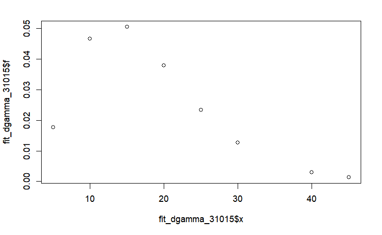

```r
plot(x= fit_dgamma_31015$x, y=fit_dgamma_31015$f)
```

```r
#Calculating exponential distribution
exp_w310_2015_ <- fitdistrplus::fitdist(data=w_310_2015$DURATION%>% unlist() %>% as.numeric(), "exp", method="mle", optim.method="Nelder-Mead", weights = round(w_310_2015$WGHT_EPI))
summary(exp_w310_2015_)
```

```
Fitting of the distribution ' exp ' by maximum likelihood
Parameters :
```

|  | estimate | Std. Error |
| --- | --- | --- |
| rate | 0.05740385 | 0.0002177277 |

```
Loglikelihood:  -267990.7   AIC:  535983.3   BIC:  535984.9
```

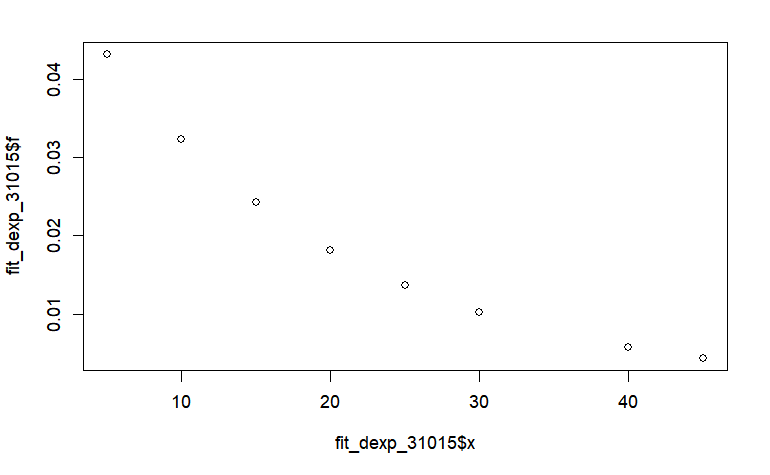

```r
fit_dexp_31015 <- data.frame(f = dexp(w_310_2015$DURATION, rate = exp_w310_2015_$estimate[1]),
                       x = w_310_2015$DURATION, type = "exp")

plot(x = fit_dexp_31015$x, y = fit_dexp_31015$f)
```

```r
#Calculating normal distribution

norm_w310_2015_ <- fitdistrplus::fitdist(data=w_310_2015$DURATION%>% unlist() %>% as.numeric(), "norm", method="mle", optim.method="Nelder-Mead", weights = round(w_310_2015$WGHT_EPI))
summary(norm_w310_2015_)
```

```
Fitting of the distribution ' norm ' by maximum likelihood
Parameters :
```

|  | estimate | Std. Error |
| --- | --- | --- |
| mean | 17.423298 | 0.03218494 |
| sd | 8.482975 | 0.02275989 |

```
Loglikelihood:  -247097.8   AIC:  494199.5   BIC:  494202.7
Correlation matrix:
             mean           sd
mean 1.0000000000 0.0003097587
sd   0.0003097587 1.0000000000
```

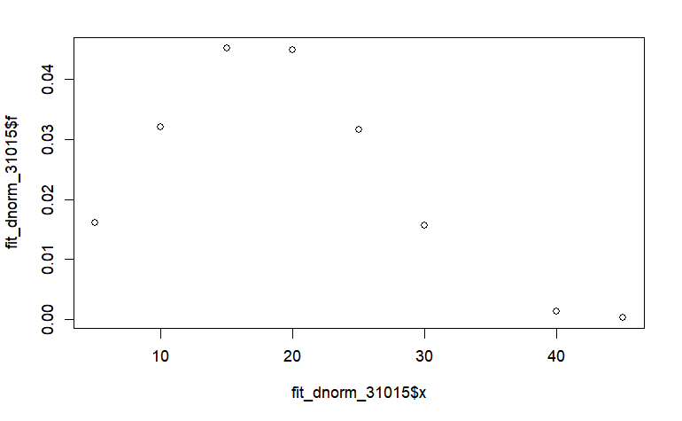

```r
fit_dnorm_31015 <- data.frame(f = dnorm(w_310_2015$DURATION, mean = norm_w310_2015_$estimate[1], sd = norm_w310_2015_$estimate[2]), x = w_310_2015$DURATION, type = "norm")

plot(x= fit_dnorm_31015$x, y=fit_dnorm_31015$f)
```

```r
#Calculating lognormal distribution

lnorm_w310_2015_ <- fitdistrplus::fitdist(data=w_310_2015$DURATION%>% unlist() %>% as.numeric(), "lnorm", method="mle", optim.method="Nelder-Mead", weights = round(w_310_2015$WGHT_EPI))
summary(lnorm_w310_2015_)
```

```
Fitting of the distribution ' lnorm ' by maximum likelihood
Parameters :
```

|  | estimate | Std. Error |
| --- | --- | --- |
| meanlog | 2.7305064 | 0.001987399 |
| sdlog | 0.5238183 | 0.001405109 |

```
Loglikelihood:  -243345.4   AIC:  486694.9   BIC:  486698
Correlation matrix:
              meanlog         sdlog
meanlog  1.000000e+00 -5.350821e-05
sdlog   -5.350821e-05  1.000000e+00
```

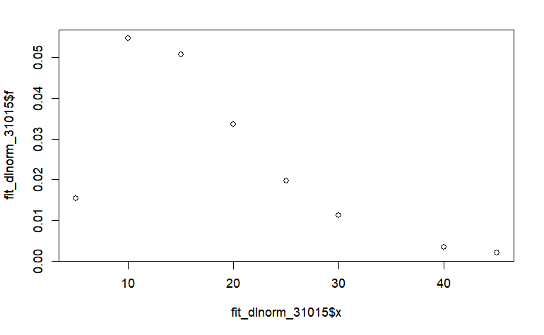

```r
fit_dlnorm_31015 <- data.frame(f = dlnorm(w_310_2015$DURATION, meanlog = lnorm_w310_2015_$estimate[1], sdlog = lnorm_w310_2015_$estimate[2]), x = w_310_2015$DURATION, type = "lnorm")

plot(x= fit_dlnorm_31015$x, y=fit_dlnorm_31015$f)
```

```r
#Calculating weibull distribution

weibull_w310_2015_ <- fitdistrplus::fitdist(data=w_310_2015$DURATION%>% unlist() %>% as.numeric(), "weibull", method="mle", optim.method="Nelder-Mead", weights = round(w_310_2015$WGHT_EPI))
summary(weibull_w310_2015_)
```

```
Fitting of the distribution ' weibull ' by maximum likelihood
Parameters :
```

|  | estimate | Std. Error |
| --- | --- | --- |
| shape | 2.19297 | 0.006365945 |
| scale | 19.73552 | 0.036091248 |

```
Loglikelihood:  -242971.2   AIC:  485946.3   BIC:  485949.5
Correlation matrix:
          shape     scale
shape 1.0000000 0.3237583
scale 0.3237583 1.0000000
```

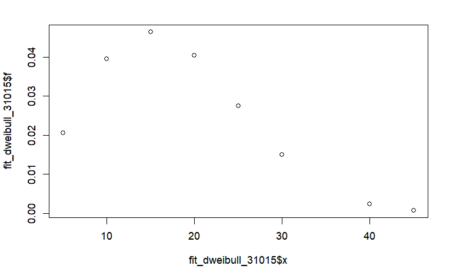

```r
fit_dweibull_31015 <- data.frame(f = dweibull(w_310_2015$DURATION, shape = weibull_w310_2015_$estimate[1], scale = weibull_w310_2015_$estimate[2]), x = w_310_2015$DURATION, type = "weibull")

plot(x= fit_dweibull_31015$x, y=fit_dweibull_31015$f)
```

Now let’s compare these models AIC and BIC to see which fits the walk data best:

```r
#comparing these models AIC and BIC to see which fits the walk data best:
broom::glance(MASS::fitdistr(w_310_2015$DURATION%>% unlist() %>% as.numeric(),"gamma"))
```

| logLik | AIC | BIC | nobs |
| --- | --- | --- | --- |
| -127.2346 | 258.4692 | 261.6362 | 36 |

```r
broom::glance(MASS::fitdistr(w_310_2015$DURATION%>% unlist() %>% as.numeric(),"exponential"))
```

| logLik | AIC | BIC | nobs |
| --- | --- | --- | --- |
| -136.3713 | 274.7427 | 276.3262 | 36 |

```r
broom::glance(MASS::fitdistr(w_310_2015$DURATION%>% unlist() %>% as.numeric(),"normal"))
```

| logLik | AIC | BIC | nobs |
| --- | --- | --- | --- |
| -132.7798 | 269.5596 | 272.7266 | 36 |

```r
broom::glance(MASS::fitdistr(w_310_2015$DURATION%>% unlist() %>% as.numeric(),"lognormal"))
```

| logLik | AIC | BIC | nobs |
| --- | --- | --- | --- |
| -127.0103 | 258.0207 | 261.1877 | 36 |

```r
broom::glance(MASS::fitdistr(w_310_2015$DURATION%>% unlist() %>% as.numeric(),"weibull"))
```

| logLik | AIC | BIC | nobs |
| --- | --- | --- | --- |
| -128.2322 | 260.4645 | 263.6315 | 36 |

```r
walking_31015_gamma <- gamma_w310_2015_
w_310_2015 <- w_310_2015 %>%
 mutate(f_310 = dgamma(DURATION, walking_31015_gamma$estimate["shape"], walking_31015_gamma$estimate["rate"]))
summary(w_310_2015$f_310)
```

```
    Min.  1st Qu.   Median     Mean  3rd Qu.     Max.
0.001312 0.017709 0.042290 0.034566 0.047590 0.050465
```

## Calculating impedance function for cycling in 2015

```r
count <- sum(cycling_2015$DURATION > 100)
print (count)
```

```
[1] 4
```

```r
cycling_2015 <- cycling_2015 %>% filter(DURATION < 100)
summary(cycling_2015$DURATION)
```

```
   Min. 1st Qu.  Median    Mean 3rd Qu.    Max.
   5.00   15.00   15.00   21.66   30.00   80.00
```

using a skew vs. kurtois graph to descriptive statistics of data:

```
summary statistics
------
min:  5   max:  80
median:  15
mean:  21.65899
estimated sd:  14.23233
estimated skewness:  1.771583
estimated kurtosis:  6.639531
```

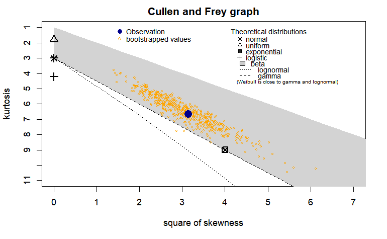

```r
# creating a skew vs. kurtois graph for cycling 2015

descdist(cycling_2015$DURATION %>% unlist() %>% as.numeric(), discrete=FALSE, boot=500)
```

As shown in the Cullen and Frey graph, we see that gamma, weibull and exponential will likely be the best fit according to the graph above. Then we compare these models to find the best model.

```r
summary(cycling_2015$DURATION)
```

```
   Min. 1st Qu.  Median    Mean 3rd Qu.    Max.
   5.00   15.00   15.00   21.66   30.00   80.00
```

```r
# Based on the skew vs. kurtois graph the best distribution

#Calculating gamma distribution

gamma_c_2015_ <- fitdistrplus::fitdist(data=cycling_2015$DURATION%>% unlist() %>% as.numeric(), "gamma", method="mle", optim.method="Nelder-Mead", weights = round(cycling_2015$WGHT_EPI))


fit_dgamma <- data.frame(f = dgamma(cycling_2015$DURATION, shape = gamma_c_2015_$estimate[1], rate = gamma_c_2015_$estimate[2]), x = cycling_2015$DURATION, type = "gamma")

summary(gamma_c_2015_)

plot(x= fit_dgamma$x, y=fit_dgamma$f)


#Calculating weibul distribution

weibull_c_2015_ <- fitdistrplus::fitdist(data=cycling_2015$DURATION%>% unlist() %>% as.numeric(), "weibull", method="mle", optim.method="Nelder-Mead", weights = round(cycling_2015$WGHT_EPI))


fit_dweibull <- data.frame(f = dweibull(cycling_2015$DURATION, shape = weibull_c_2015_$estimate[1], scale = weibull_c_2015_$estimate[2]), x = cycling_2015$DURATION, type = "weibull")

summary(weibull_c_2015_)

plot(x= fit_dweibull$x, y=fit_dweibull$f)


#Calculating exponential distribution
exp_c_2015_ <- fitdistrplus::fitdist(data=cycling_2015$DURATION%>% unlist() %>% as.numeric(), "exp", method="mle", optim.method="Nelder-Mead", weights = round(cycling_2015$WGHT_EPI))

summary(exp_c_2015_)

fit_dexp <- data.frame(f = dexp(cycling_2015$DURATION, rate = exp_c_2015_$estimate[1]), x = cycling_2015$DURATION, type = "exp")

plot(x= fit_dexp$x, y=fit_dexp$f)
```

[output not shown]

Now let’s compare these models based on AIC and BIC to see which fits the walk data best:

```r
#comparing these models AIC and BIC to see which fits the walk data best:
broom::glance(MASS::fitdistr(cycling_2015$DURATION%>% unlist() %>% as.numeric(),"gamma"))
```

| logLik | AIC | BIC | nobs |
| --- | --- | --- | --- |
| -831.4976 | 1666.995 | 1673.755 | 217 |

```r
broom::glance(MASS::fitdistr(cycling_2015$DURATION%>% unlist() %>% as.numeric(),"weibull"))
```

| logLik | AIC | BIC | nobs |
| --- | --- | --- | --- |
| -842.9657 | 1689.931 | 1696.691 | 217 |

```r
broom::glance(MASS::fitdistr(cycling_2015$DURATION%>% unlist() %>% as.numeric(),"exponential"))
```

| logLik | AIC | BIC | nobs |
| --- | --- | --- | --- |
| -884.3662 | 1770.732 | 1774.112 | 217 |

```r
NA
```

So, gamma has largest logLik and the smallest AIC and BIC. we will pick gamma function for cycling trips in 2015!

```r
cycling_2015_gamma <- gamma_c_2015_
cycling_2015 <- cycling_2015 %>%
 mutate(f = dgamma(DURATION, cycling_2015_gamma$estimate["shape"], cycling_2015_gamma$estimate["rate"] ))
summary(cycling_2015$f)
```

```
     Min.   1st Qu.    Median      Mean   3rd Qu.      Max.
0.0003146 0.0197678 0.0293622 0.0254256 0.0335914 0.0335914
```

###Destination : Cycling- Home (300), 2015

using a skew vs. kurtois graph to descriptive statistics of data

```
summary statistics
------
min:  5   max:  80
median:  20
mean:  23.31731
estimated sd:  15.98863
estimated skewness:  1.533179
estimated kurtosis:  5.337804
```

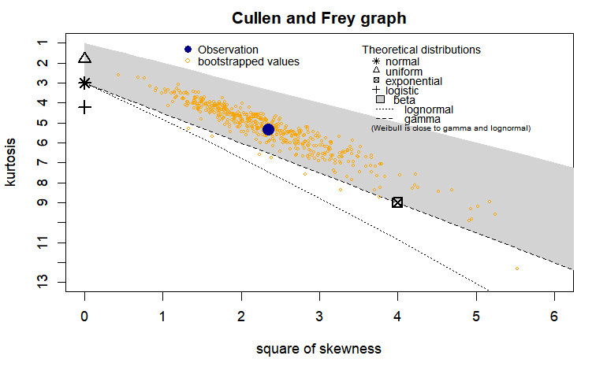

```r
# creating a skew vs. kurtois graph for cycling 2015

# Filter the data based on the "destination" column
 c_300_2015 <- cycling_2015 %>%
  filter(destination == "300")
descdist(c_300_2015$DURATION %>% unlist() %>% as.numeric(), discrete=FALSE, boot=500)
```

As shown in the Cullen and Frey graph, we see that gamma, weibull and exponential will likely be the best fit according to the graph above. Then we compare these models to find the best model.

```r
# Based on the skew vs. kurtois graph the best distribution

#Calculating gamma distribution
gamma_c300_2015_ <- fitdistrplus::fitdist(data=c_300_2015$DURATION%>% unlist() %>% as.numeric(), "gamma", method="mle", optim.method="Nelder-Mead", weights = round(c_300_2015$WGHT_EPI))
fit_dgamma_c30015 <- data.frame(f_300 = dgamma(c_300_2015$DURATION, shape = gamma_c300_2015_$estimate[1], rate = gamma_c300_2015_$estimate[2]), x = c_300_2015$DURATION, type = "Gamma")

summary(gamma_c300_2015_)
```

```
Fitting of the distribution ' gamma ' by maximum likelihood
Parameters :
```

|  | estimate | Std. Error |
| --- | --- | --- |
| shape | 2.48255342 | 0.0069475024 |
| rate | 0.09735022 | 0.0003018279 |

```
Loglikelihood:  -915481.7   AIC:  1830967   BIC:  1830973
Correlation matrix:
          shape      rate
shape 1.0000000 0.9024668
rate  0.9024668 1.0000000
```

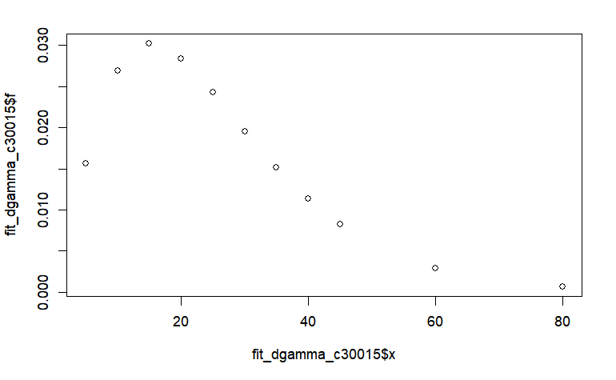

```r
plot(x= fit_dgamma_c30015$x, y=fit_dgamma_c30015$f)
```

```r
#Calculating weibull distribution
weibull_c300_2015_ <- fitdistrplus::fitdist(data=c_300_2015$DURATION%>% unlist() %>% as.numeric(), "weibull", method="mle", optim.method="Nelder-Mead", weights = round(c_300_2015$WGHT_EPI))
summary(weibull_c300_2015_)
```

```
Fitting of the distribution ' weibull ' by maximum likelihood
Parameters :
```

|  | estimate | Std. Error |
| --- | --- | --- |
| shape | 1.571805 | 0.002433718 |
| scale | 28.619221 | 0.040641914 |

```
Loglikelihood:  -923652.5   AIC:  1847309   BIC:  1847314
Correlation matrix:
          shape     scale
shape 1.0000000 0.3338157
scale 0.3338157 1.0000000
```

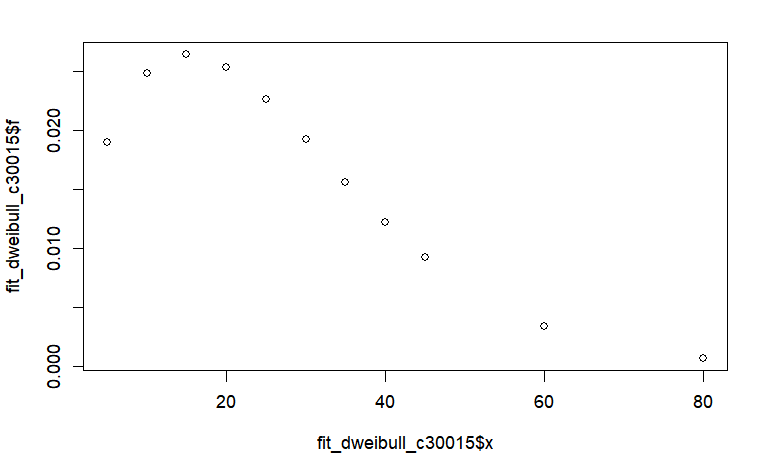

```r
fit_dweibull_c30015 <- data.frame(f = dweibull(c_300_2015$DURATION, shape = weibull_c300_2015_$estimate[1], scale = weibull_c300_2015_$estimate[2]), x = c_300_2015$DURATION, type = "weibull")

plot(x= fit_dweibull_c30015$x, y=fit_dweibull_c30015$f)
```

```r
#Calculating exponential distribution
exp_c300_2015_ <- fitdistrplus::fitdist(data=c_300_2015$DURATION%>% unlist() %>% as.numeric(), "exp", method="mle", optim.method="Nelder-Mead", weights = round(c_300_2015$WGHT_EPI))
summary(exp_c300_2015_)
```

```
Fitting of the distribution ' exp ' by maximum likelihood
Parameters :
```

|  | estimate | Std. Error |
| --- | --- | --- |
| rate | 0.03920103 | 8.244551e-05 |

```
Loglikelihood:  -957033.3   AIC:  1914069   BIC:  1914071
```

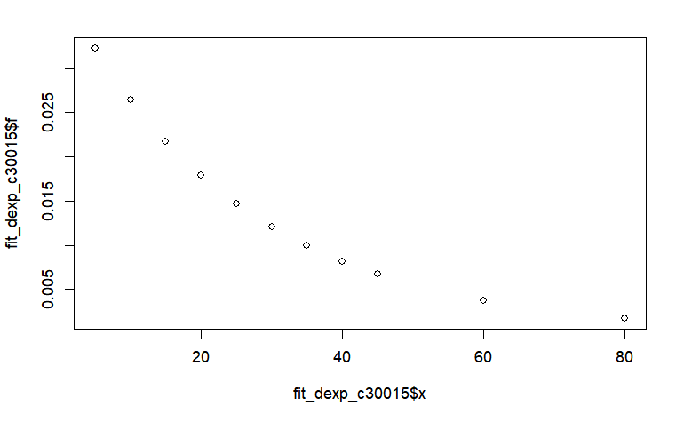

```r
fit_dexp_c30015 <- data.frame(f = dexp(c_300_2015$DURATION, exp_c300_2015_$estimate[1]),
                       x = c_300_2015$DURATION, type = "exp")

plot(x = fit_dexp_c30015$x, y = fit_dexp_c30015$f)
```

Now let’s compare these models AIC and BIC to see which fits the walk data best:

```r
#comparing these models AIC and BIC to see which fits the walk data best:
broom::glance(MASS::fitdistr(c_300_2015$DURATION%>% unlist() %>% as.numeric(),"gamma"))
```

| logLik | AIC | BIC | nobs |
| --- | --- | --- | --- |
| -411.0203 | 826.0406 | 831.3294 | 104 |

```r
broom::glance(MASS::fitdistr(c_300_2015$DURATION%>% unlist() %>% as.numeric(),"weibull"))
```

| logLik | AIC | BIC | nobs |
| --- | --- | --- | --- |
| -415.0874 | 834.1747 | 839.4635 | 104 |

```r
broom::glance(MASS::fitdistr(c_300_2015$DURATION%>% unlist() %>% as.numeric(),"exponential"))
```

| logLik | AIC | BIC | nobs |
| --- | --- | --- | --- |
| -431.5164 | 865.0327 | 867.6771 | 104 |

So, gamma has largest logLik and the smallest AIC and BIC. we will pick gamma function for cycling trips in 2015!

```r
cycling_30015_gamma <- gamma_c300_2015_
c_300_2015 <- c_300_2015 %>%
 mutate(f_300 = dgamma(DURATION, cycling_30015_gamma$estimate["shape"], cycling_30015_gamma$estimate["rate"]))
summary(c_300_2015$f_300)
```

```
     Min.   1st Qu.    Median      Mean   3rd Qu.      Max.
0.0006446 0.0195750 0.0269103 0.0224138 0.0284070 0.0301710
```

###Destination : Cycling - work or school (301), 2015 using a skew vs. kurtois graph to descriptive statistics of data

```
summary statistics
------
min:  5   max:  60
median:  15
mean:  21.23188
estimated sd:  11.29178
estimated skewness:  1.167132
estimated kurtosis:  4.159448
```

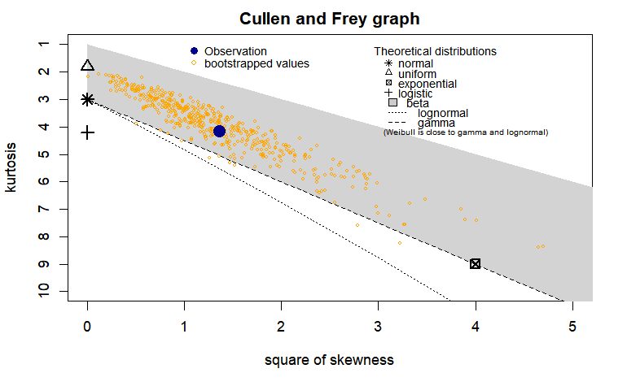

```r
# creating a skew vs. kurtois graph for cycling 2015

# Filter the data based on the "destination" column
 c_301_2015 <- cycling_2015 %>%
  filter(destination == "301")
descdist(c_301_2015$DURATION %>% unlist() %>% as.numeric(), discrete=FALSE, boot=500)
```

As shown in the Cullen and Frey graph, we see that gamma, weibull, normal, lognormal and exponential will likely be the best fit according to the graph above. Then we compare these models to find the best model.

```r
# Based on the skew vs. kurtois graph the best distribution

#Calculating gamma distribution

gamma_c301_2015_ <- fitdistrplus::fitdist(data=c_301_2015$DURATION%>% unlist() %>% as.numeric(), "gamma", method="mle", optim.method="Nelder-Mead", weights = round(c_301_2015$WGHT_EPI))
fit_dgamma_30115 <- data.frame(f = dgamma(c_301_2015$DURATION, shape = gamma_c301_2015_$estimate[1], rate = gamma_c301_2015_$estimate[2]), x = c_301_2015$DURATION, type = "Gamma")

summary(gamma_c301_2015_)
```

```
Fitting of the distribution ' gamma ' by maximum likelihood
Parameters :
```

|  | estimate | Std. Error |
| --- | --- | --- |
| shape | 4.5894363 | 0.0151107159 |
| rate | 0.2111502 | 0.0007346703 |

```
Loglikelihood:  -629611.9   AIC:  1259228   BIC:  1259232
Correlation matrix:
          shape      rate
shape 1.0000000 0.9462558
rate  0.9462558 1.0000000
```

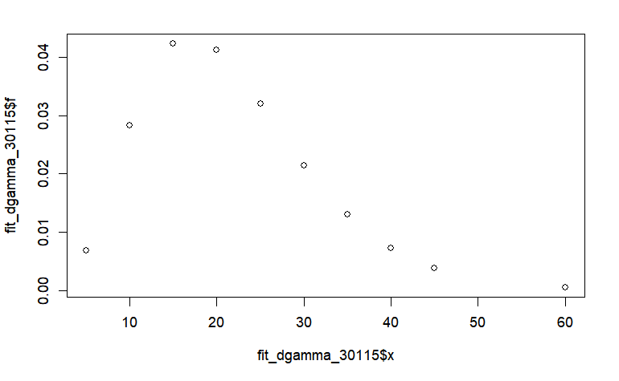

```r
plot(x= fit_dgamma_30115$x, y=fit_dgamma_30115$f)
```

```r
#Calculating weibull distribution
weibull_c301_2015_ <- fitdistrplus::fitdist(data=c_301_2015$DURATION%>% unlist() %>% as.numeric(), "weibull", method="mle", optim.method="Nelder-Mead", weights = round(c_301_2015$WGHT_EPI))
summary(weibull_c301_2015_)
```

```
Fitting of the distribution ' weibull ' by maximum likelihood
Parameters :
```

|  | estimate | Std. Error |
| --- | --- | --- |
| shape | 2.309992 | 0.004214674 |
| scale | 24.592509 | 0.027139817 |

```
Loglikelihood:  -632347.3   AIC:  1264699   BIC:  1264703
Correlation matrix:
          shape     scale
shape 1.0000000 0.3250591
scale 0.3250591 1.0000000
```

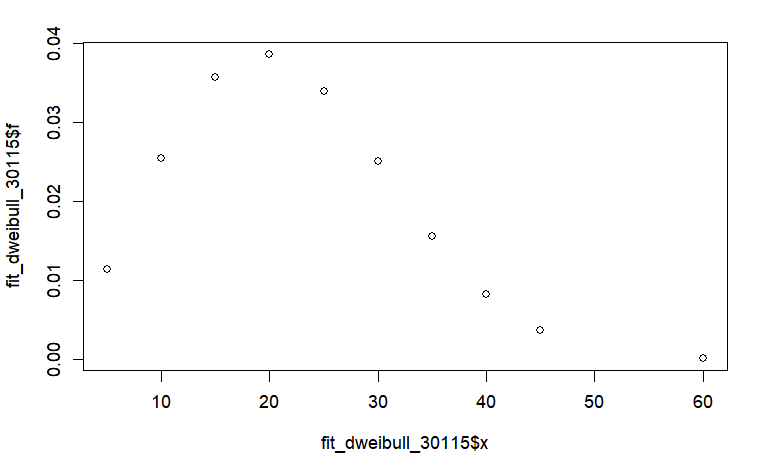

```r
fit_dweibull_30115 <- data.frame(f = dweibull(c_301_2015$DURATION, shape = weibull_c301_2015_$estimate[1], scale = weibull_c301_2015_$estimate[2]), x = c_301_2015$DURATION, type = "weibull")

plot(x= fit_dweibull_30115$x, y=fit_dweibull_30115$f)
```

```r
#Calculating exponential distribution
exp_c301_2015_ <- fitdistrplus::fitdist(data=c_301_2015$DURATION%>% unlist() %>% as.numeric(), "exp", method="mle", optim.method="Nelder-Mead", weights = round(c_301_2015$WGHT_EPI))
summary(exp_c301_2015_)
```

```
Fitting of the distribution ' exp ' by maximum likelihood
Parameters :
```

|  | estimate | Std. Error |
| --- | --- | --- |
| rate | 0.04603189 | 0.00011092 |

```
Loglikelihood:  -701803.4   AIC:  1403609   BIC:  1403611
```

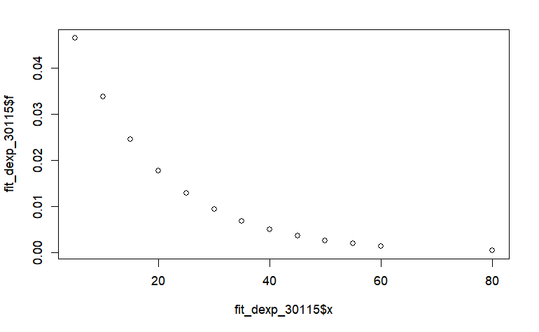

```r
fit_dexp_30115 <- data.frame(f = dexp(w_301_2015$DURATION, rate =exp_w301_2015_$estimate[1]),
                       x = w_301_2015$DURATION, type = "exp")

plot(x = fit_dexp_30115$x, y = fit_dexp_30115$f)
```

```r
#Calculating normal distribution
norm_c301_2015_ <- fitdistrplus::fitdist(data=c_301_2015$DURATION%>% unlist() %>% as.numeric(), "norm", method="mle", optim.method="Nelder-Mead", weights = round(c_301_2015$WGHT_EPI))
summary(norm_c301_2015_)
```

```
Fitting of the distribution ' norm ' by maximum likelihood
Parameters :
```

|  | estimate | Std. Error |
| --- | --- | --- |
| mean | 21.73196 | 0.02419265 |
| sd | 10.03523 | 0.01710841 |

```
Loglikelihood:  -640930.7   AIC:  1281865   BIC:  1281870
Correlation matrix:
             mean           sd
mean 1.000000e+00 7.919045e-05
sd   7.919045e-05 1.000000e+00
```

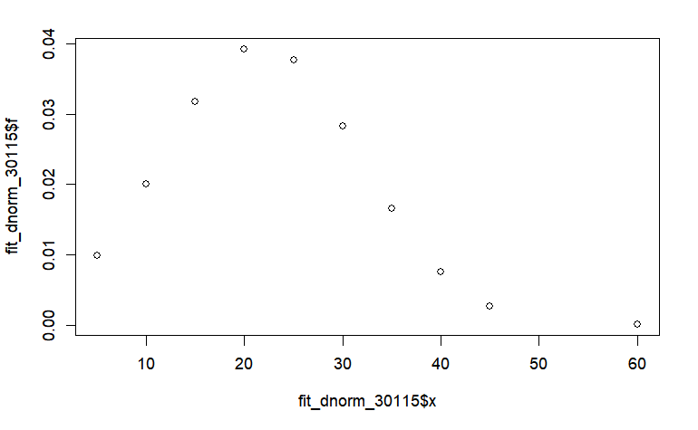

```r
fit_dnorm_30115 <- data.frame(f = dnorm(c_301_2015$DURATION, mean = norm_c301_2015_$estimate[1], sd = norm_c301_2015_$estimate[2]), x = c_301_2015$DURATION, type = "norm")

plot(x= fit_dnorm_30115$x, y=fit_dnorm_30115$f)
```

```r
#Calculating lognormal distribution
lnorm_c301_2015_ <- fitdistrplus::fitdist(data=c_301_2015$DURATION%>% unlist() %>% as.numeric(), "lnorm", method="mle", optim.method="Nelder-Mead", weights = round(c_301_2015$WGHT_EPI))
summary(lnorm_c301_2015_)
```

```
Fitting of the distribution ' lnorm ' by maximum likelihood
Parameters :
```

|  | estimate | Std. Error |
| --- | --- | --- |
| meanlog | 2.9658723 | 0.0011910261 |
| sdlog | 0.4940433 | 0.0008422227 |

```
Loglikelihood:  -633126.6   AIC:  1266257   BIC:  1266262
Correlation matrix:
             meanlog        sdlog
meanlog 1.000000e+00 3.953752e-05
sdlog   3.953752e-05 1.000000e+00
```

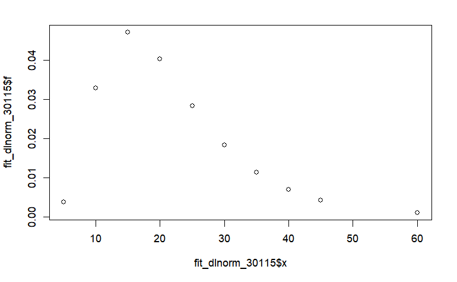

```r
fit_dlnorm_30115 <- data.frame(f = dlnorm(c_301_2015$DURATION, meanlog = lnorm_c301_2015_$estimate[1], sdlog = lnorm_c301_2015_$estimate[2]), x = c_301_2015$DURATION, type = "lnorm")

plot(x= fit_dlnorm_30115$x, y=fit_dlnorm_30115$f)
```

Now let’s compare these models AIC and BIC to see which fits the walk data best:

```r
#comparing these models AIC and BIC to see which fits the walk data best:
broom::glance(MASS::fitdistr(c_301_2015$DURATION%>% unlist() %>% as.numeric(),"gamma"))
```

| logLik | AIC | BIC | nobs |
| --- | --- | --- | --- |
| -255.259 | 514.518 | 518.9862 | 69 |

```r
broom::glance(MASS::fitdistr(c_301_2015$DURATION%>% unlist() %>% as.numeric(),"weibull"))
```

| logLik | AIC | BIC | nobs |
| --- | --- | --- | --- |
| -258.0986 | 520.1972 | 524.6654 | 69 |

```r
broom::glance(MASS::fitdistr(c_301_2015$DURATION%>% unlist() %>% as.numeric(),"exponential"))
```

| logLik | AIC | BIC | nobs |
| --- | --- | --- | --- |
| -279.8298 | 561.6596 | 563.8937 | 69 |

```r
broom::glance(MASS::fitdistr(c_301_2015$DURATION%>% unlist() %>% as.numeric(),"normal"))
```

| logLik | AIC | BIC | nobs |
| --- | --- | --- | --- |
| -264.6643 | 533.3285 | 537.7967 | 69 |

```r
broom::glance(MASS::fitdistr(c_301_2015$DURATION%>% unlist() %>% as.numeric(),"lognormal"))
```

| logLik | AIC | BIC | nobs |
| --- | --- | --- | --- |
| -254.791 | 513.582 | 518.0503 | 69 |

```r
cycling_30115_gamma <- gamma_c301_2015_
c_301_2015 <- c_301_2015 %>%
 mutate(f_301 = dgamma(DURATION, cycling_30115_gamma$estimate["shape"], cycling_30115_gamma$estimate["rate"]))
summary(c_301_2015$f_301)
```

```
     Min.   1st Qu.    Median      Mean   3rd Qu.      Max.
0.0004578 0.0214402 0.0413212 0.0305641 0.0422884 0.0422884
```

###Destination : Cycling- Business (302), 2015 using a skew vs. kurtois graph to descriptive statistics of data

```r
# creating a skew vs. kurtois graph for cycling 2015 _ Business destination

# Filter the data based on the "destination" column
 c_302_2015 <- cycling_2015 %>%
  filter(destination == "302")
count <- sum(cycling_2015$destination == "302")
print(count)
```

```
[1] 0
```

There is no available data pertaining to cycling directed towards business destinations.

###Destination : Cycling- At someone else’s home or property (303), 2015 using a skew vs. kurtois graph to descriptive statistics of data

```
summary statistics
------
min:  5   max:  40
median:  15
mean:  14.61538
estimated sd:  8.281893
estimated skewness:  2.61367
estimated kurtosis:  11.54563
```

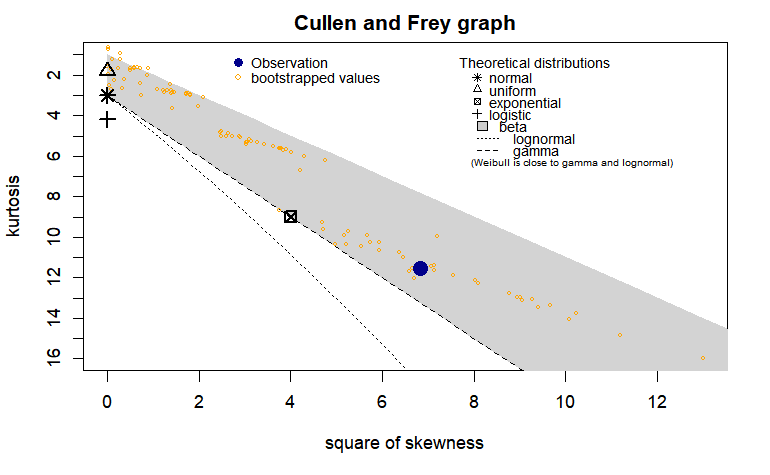

```r
# creating a skew vs. kurtois graph for cycling 2015

# Filter the data based on the "destination" column
 c_303_2015 <- cycling_2015 %>%
  filter(destination == "303")
descdist(c_303_2015$DURATION %>% unlist() %>% as.numeric(), discrete=FALSE, boot=500)
```

```r
# Based on the skew vs. kurtois graph the best distribution

#Calculating gamma distribution

gamma_c303_2015_ <- fitdistrplus::fitdist(data=c_303_2015$DURATION%>% unlist() %>% as.numeric(), "gamma", method="mle", optim.method="Nelder-Mead", weights = round(c_303_2015$WGHT_EPI))
fit_dgamma_30315 <- data.frame(f = dgamma(c_303_2015$DURATION, shape = gamma_c303_2015_$estimate[1], rate = gamma_c303_2015_$estimate[2]), x = c_303_2015$DURATION, type = "Gamma")

summary(gamma_c303_2015_)
```

```
Fitting of the distribution ' gamma ' by maximum likelihood
Parameters :
```

|  | estimate | Std. Error |
| --- | --- | --- |
| shape | 6.5839347 | 0.057779594 |
| rate | 0.4773153 | 0.004352692 |

```
Loglikelihood:  -75355.98   AIC:  150716   BIC:  150717.1
Correlation matrix:
          shape      rate
shape 1.0000000 0.9623502
rate  0.9623502 1.0000000
```

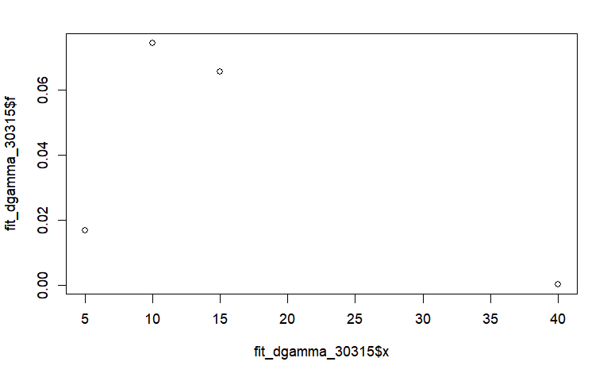

```r
plot(x= fit_dgamma_30315$x, y=fit_dgamma_30315$f)
```

```r
#Calculating exponential distribution
exp_c303_2015_ <- fitdistrplus::fitdist(data=c_303_2015$DURATION%>% unlist() %>% as.numeric(), "exp", method="mle", optim.method="Nelder-Mead", weights = round(c_303_2015$WGHT_EPI))
summary(exp_c303_2015_)
```

```
Fitting of the distribution ' exp ' by maximum likelihood
Parameters :
```

|  | estimate | Std. Error |
| --- | --- | --- |
| rate | 0.07248355 | 0.0004609181 |

```
Loglikelihood:  -89595.3   AIC:  179192.6   BIC:  179193.2
```

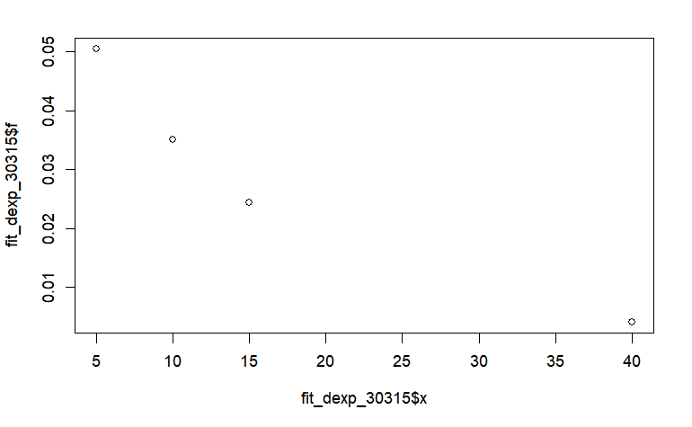

```r
fit_dexp_30315 <- data.frame(f = dexp(c_303_2015$DURATION, rate = exp_c303_2015_$estimate[1]),
                       x = c_303_2015$DURATION, type = "exp")

plot(x = fit_dexp_30315$x, y = fit_dexp_30315$f)
```

```r
#Calculating pois distribution
pois_c303_2015_ <- fitdistrplus::fitdist(data=c_303_2015$DURATION%>% unlist() %>% as.numeric(), "pois", method="mle", optim.method="Nelder-Mead", weights = round(c_303_2015$WGHT_EPI))
fit_dpois_30315 <- data.frame(f = dpois(c_303_2015$DURATION, lambda = pois_c303_2015_$estimate[1]), x = c_303_2015$DURATION, type = "pois")

summary(pois_c303_2015_)
```

```
Fitting of the distribution ' pois ' by maximum likelihood
Parameters :
```

|  | estimate | Std. Error |
| --- | --- | --- |
| lambda | 13.7947 | 0.02362265 |

```
Loglikelihood:  -81969.75   AIC:  163941.5   BIC:  163942.1
```

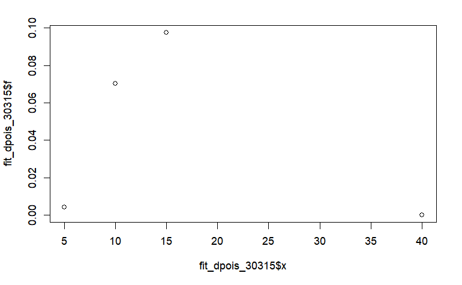

```r
plot(x= fit_dpois_30315$x, y=fit_dpois_30315$f)
```

```r
#Calculating normal distribution
norm_c303_2015_ <- fitdistrplus::fitdist(data=c_303_2015$DURATION%>% unlist() %>% as.numeric(), "norm", method="mle", optim.method="Nelder-Mead", weights = round(c_303_2015$WGHT_EPI))
fit_dnorm_30315 <- data.frame(f = dnorm(c_303_2015$DURATION, mean = norm_c303_2015_$estimate[1], sd = norm_c303_2015_$estimate[2]), x = c_303_2015$DURATION, type = " norm")

summary(norm_c303_2015_)
```

```
Fitting of the distribution ' norm ' by maximum likelihood
Parameters :
```

|  | estimate | Std. Error |
| --- | --- | --- |
| mean | 13.79338 | 0.03877678 |
| sd | 6.09684 | 0.02741094 |

```
Loglikelihood:  -79772.52   AIC:  159549   BIC:  159550.2
Correlation matrix:
             mean           sd
mean  1.000000000 -0.000223884
sd   -0.000223884  1.000000000
```

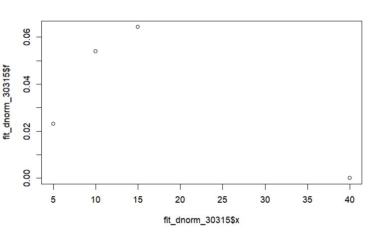

```r
plot(x= fit_dnorm_30315$x, y=fit_dnorm_30315$f)
```

Now let’s compare these models AIC and BIC to see which fits the walk data best:

```r
#comparing these models AIC and BIC to see which fits the walk data best:
broom::glance(MASS::fitdistr(c_303_2015$DURATION%>% unlist() %>% as.numeric(),"gamma"))
```

| logLik | AIC | BIC | nobs |
| --- | --- | --- | --- |
| -42.17 | 88.33999 | 89.46989 | 13 |

```r
broom::glance(MASS::fitdistr(c_303_2015$DURATION%>% unlist() %>% as.numeric(),"poisson"))
```

| logLik | AIC | BIC | nobs |
| --- | --- | --- | --- |
| -51.22649 | 104.453 | 105.0179 | 13 |

```r
broom::glance(MASS::fitdistr(c_303_2015$DURATION%>% unlist() %>% as.numeric(),"exponential"))
```

| logLik | AIC | BIC | nobs |
| --- | --- | --- | --- |
| -47.86697 | 97.73394 | 98.29889 | 13 |

```r
broom::glance(MASS::fitdistr(c_303_2015$DURATION%>% unlist() %>% as.numeric(),"normal"))
```

| logLik | AIC | BIC | nobs |
| --- | --- | --- | --- |
| -45.40885 | 94.81771 | 95.9476 | 13 |

So, gamma has largest logLik and the smallest AIC and BIC. we will pick gamma function for cycling trips in 2015!(303)

```r
cycling_30315_gamma <- gamma_c303_2015_
c_303_2015 <- c_303_2015 %>%
 mutate(f_303 = dgamma(DURATION, cycling_30315_gamma$estimate["shape"], cycling_30315_gamma$estimate["rate"]))
summary(c_303_2015$f_303)
```

```
     Min.   1st Qu.    Median      Mean   3rd Qu.      Max.
0.0001034 0.0658010 0.0658010 0.0596212 0.0743751 0.0743751
```

###Destination : Cycling - Outdoors (305), 2015 using a skew vs. kurtois graph to descriptive statistics of data

```r
# creating a skew vs. kurtois graph for cycling 2015

# Filter the data based on the "destination" column
 c_305_2015 <- cycling_2015 %>%
  filter(destination == "305")

count <- sum(cycling_2015$destination == "305")
print(count)
```

```
[1] 2
```

```r
#descdist(c_305_2015$DURATION %>% unlist() %>% as.numeric(), discrete=FALSE, boot=500)
```

###Destination : Cycling - Grocery store, other stores or mall (306), 2015 using a skew vs. kurtois graph to descriptive statistics of data

```r
# creating a skew vs. kurtois graph for cycling 2015

# Filter the data based on the "destination" column
 c_306_2015 <- cycling_2015 %>%
  filter(destination == "306")
descdist(c_306_2015$DURATION %>% unlist() %>% as.numeric(), discrete=FALSE, boot=500)
```

[output not shown]

```r
# Based on the skew vs. kurtois graph the best distribution

#Calculating normal distribution

norm_c306_2015_ <- fitdistrplus::fitdist(data=c_306_2015$DURATION%>% unlist() %>% as.numeric(), "norm", method="mle", optim.method="Nelder-Mead", weights = round(c_306_2015$WGHT_EPI))
summary(norm_c306_2015_)
```

```
Fitting of the distribution ' norm ' by maximum likelihood
Parameters :
```

|  | estimate | Std. Error |
| --- | --- | --- |
| mean | 28.34643 | 0.1641174 |
| sd | 27.78192 | 0.1160353 |

```
Loglikelihood:  -135926.9   AIC:  271857.7   BIC:  271859.3
Correlation matrix:
              mean            sd
mean  1.0000000000 -0.0003105107
sd   -0.0003105107  1.0000000000
```

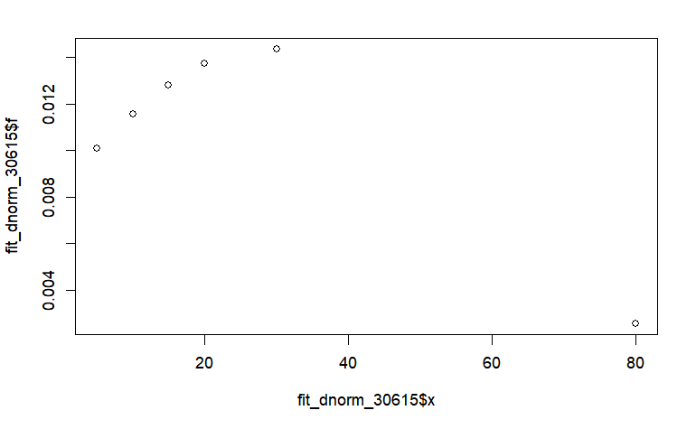

```r
fit_dnorm_30615 <- data.frame(f = dnorm(c_306_2015$DURATION, mean = norm_c306_2015_$estimate[1], sd = norm_c306_2015_$estimate[2]), x = c_306_2015$DURATION, type = "norm")

plot(x= fit_dnorm_30615$x, y=fit_dnorm_30615$f)
```

```r
#Calculating lognormal distribution

lnorm_c306_2015_ <- fitdistrplus::fitdist(data=c_306_2015$DURATION%>% unlist() %>% as.numeric(), "lnorm", method="mle", optim.method="Nelder-Mead", weights = round(c_306_2015$WGHT_EPI))
summary(lnorm_c306_2015_)
```

```
Fitting of the distribution ' lnorm ' by maximum likelihood
Parameters :
```

|  | estimate | Std. Error |
| --- | --- | --- |
| meanlog | 2.9219143 | 0.005283816 |
| sdlog | 0.8944487 | 0.003735793 |

```
Loglikelihood:  -121196.8   AIC:  242397.7   BIC:  242399.2
Correlation matrix:
             meanlog        sdlog
meanlog 1.000000e+00 1.246071e-05
sdlog   1.246071e-05 1.000000e+00
```

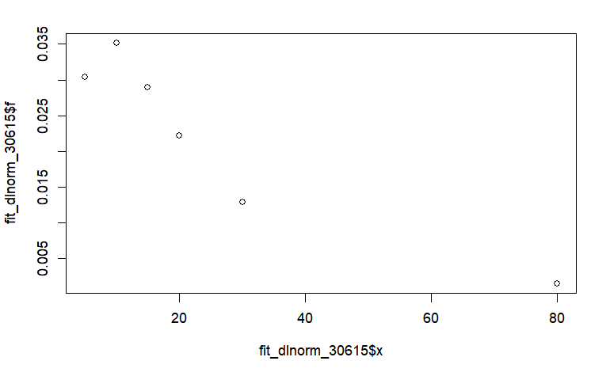

```r
fit_dlnorm_30615 <- data.frame(f = dlnorm(c_306_2015$DURATION, meanlog = lnorm_c306_2015_$estimate[1], sdlog = lnorm_c306_2015_$estimate[2]), x = c_306_2015$DURATION, type = "lnorm")

plot(x= fit_dlnorm_30615$x, y=fit_dlnorm_30615$f)
```

```r
#Calculating gamma distribution

gamma_c306_2015_ <- fitdistrplus::fitdist(data=c_306_2015$DURATION%>% unlist() %>% as.numeric(), "gamma", method="mle", optim.method="Nelder-Mead", weights = round(c_306_2015$WGHT_EPI))
summary(gamma_c306_2015_)
```

```
Fitting of the distribution ' gamma ' by maximum likelihood
Parameters :
```

|  | estimate | Std. Error |
| --- | --- | --- |
| shape | 1.32456119 | 0.0099707041 |
| rate | 0.04670841 | 0.0004252753 |

```
Loglikelihood:  -123857.1   AIC:  247718.2   BIC:  247719.7
Correlation matrix:
          shape      rate
shape 1.0000000 0.8261267
rate  0.8261267 1.0000000
```

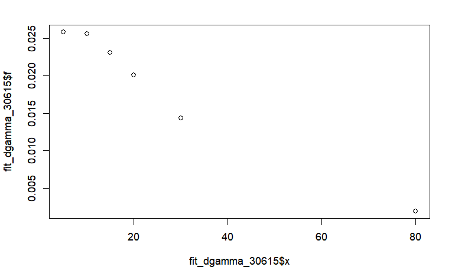

```r
fit_dgamma_30615 <- data.frame(f = dgamma(c_306_2015$DURATION, shape = gamma_c306_2015_$estimate[1], rate = gamma_c306_2015_$estimate[2]), x = c_306_2015$DURATION, type = "gamma")

plot(x= fit_dgamma_30615$x, y=fit_dgamma_30615$f)
```

```r
#Calculating logistic distribution
logis_c306_2015_ <- fitdistrplus::fitdist(data=c_306_2015$DURATION%>% unlist() %>% as.numeric(), "logis", method="mle", optim.method="Nelder-Mead", weights = round(c_306_2015$WGHT_EPI))
summary(logis_c306_2015_)
```

```
Fitting of the distribution ' logis ' by maximum likelihood
Parameters :
```

|  | estimate | Std. Error |
| --- | --- | --- |
| location | 22.54537 | 0.15109193 |
| scale | 14.85622 | 0.07872775 |

```
Loglikelihood:  -135594.6   AIC:  271193.2   BIC:  271194.7
Correlation matrix:
          location     scale
location 1.0000000 0.2166077
scale    0.2166077 1.0000000
```

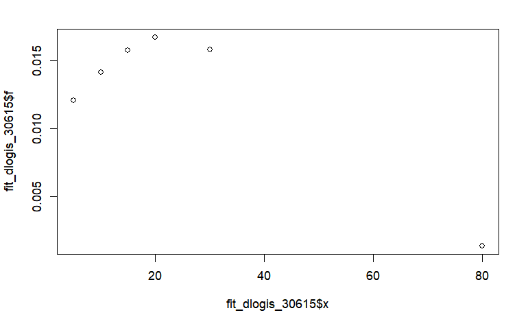

```r
fit_dlogis_30615 <- data.frame(f = dlogis(c_306_2015$DURATION, location = logis_c306_2015_$estimate[1], scale = logis_c306_2015_$estimate[2]), x = c_306_2015$DURATION, type = "logis")

plot(x= fit_dlogis_30615$x, y=fit_dlogis_30615$f)
```

Now let’s compare these models AIC and BIC to see which fits the walk data best:

```r
#comparing these models AIC and BIC to see which fits the walk data best:
broom::glance(MASS::fitdistr(w_306_2015$DURATION%>% unlist() %>% as.numeric(),"logistic"))
```

| logLik | AIC | BIC | nobs |
| --- | --- | --- | --- |
| -1336.443 | 2676.886 | 2684.631 | 355 |

```r
broom::glance(MASS::fitdistr(w_306_2015$DURATION%>% unlist() %>% as.numeric(),"lognormal"))
```

| logLik | AIC | BIC | nobs |
| --- | --- | --- | --- |
| -1235.045 | 2474.09 | 2481.834 | 355 |

```r
broom::glance(MASS::fitdistr(w_306_2015$DURATION%>% unlist() %>% as.numeric(),"gamma"))
```

| logLik | AIC | BIC | nobs |
| --- | --- | --- | --- |
| -1261.073 | 2526.145 | 2533.89 | 355 |

```r
broom::glance(MASS::fitdistr(w_306_2015$DURATION%>% unlist() %>% as.numeric(),"normal"))
```

| logLik | AIC | BIC | nobs |
| --- | --- | --- | --- |
| -1386.801 | 2777.602 | 2785.346 | 355 |

So, lognormal has largest logLik and the smallest AIC and BIC. we will pick lognormal function for walking trips in 2015!(306)

```r
cycling_30615_lnorm <- lnorm_c306_2015_
c_306_2015 <- c_306_2015 %>%
 mutate(f_306 = dlnorm(DURATION, cycling_30615_lnorm$estimate["meanlog"], cycling_30615_lnorm$estimate["sdlog"]))
summary(c_306_2015$f_306)
```

```
    Min.  1st Qu.   Median     Mean  3rd Qu.     Max.
0.001471 0.022225 0.028897 0.026251 0.031572 0.035095
```

###Destination : Cycling - Library, museum or theatre (307), 2015 using a skew vs. kurtois graph to descriptive statistics of data

```r
# creating a skew vs. kurtois graph for cycling 2015

# Filter the data based on the "destination" column
 c_307_2015 <- cycling_2015 %>%
  filter(destination == "307")
count <- sum(cycling_2015$destination == "307")
print(count)

#descdist(c_307_2015$DURATION %>% unlist() %>% as.numeric(), discrete=FALSE, boot=500)
```

[output not shown]

###Destination : Cycling - Restaurant, bar or club (309), 2015 using a skew vs. kurtois graph to descriptive statistics of data

```r
# creating a skew vs. kurtois graph for cycling 2015

# Filter the data based on the "destination" column
 c_309_2015 <- cycling_2015 %>%
  filter(destination == "309")

descdist(c_309_2015$DURATION %>% unlist() %>% as.numeric(), discrete=FALSE, boot=500)
```

[output not shown]

```r
# Based on the skew vs. kurtois graph the best distribution

#Calculating gamma distribution

gamma_c309_2015_ <- fitdistrplus::fitdist(data=c_309_2015$DURATION%>% unlist() %>% as.numeric(), "gamma", method="mle", optim.method="Nelder-Mead", weights = round(c_309_2015$WGHT_EPI))
fit_dgamma_30915 <- data.frame(f = dgamma(c_309_2015$DURATION, shape = gamma_c309_2015_$estimate[1], rate = gamma_c309_2015_$estimate[2]), x = c_309_2015$DURATION, type = "Gamma")

summary(gamma_c309_2015_)
```

```
Fitting of the distribution ' gamma ' by maximum likelihood
Parameters :
```

|  | estimate | Std. Error |
| --- | --- | --- |
| shape | 2.772234 | 0.029884643 |
| rate | 0.107505 | 0.001270212 |

```
Loglikelihood:  -62000.27   AIC:  124004.5   BIC:  124005.1
Correlation matrix:
         shape     rate
shape 1.000000 0.912238
rate  0.912238 1.000000
```

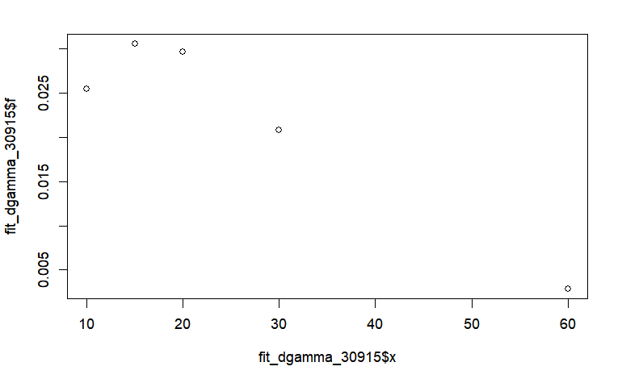

```r
plot(x= fit_dgamma_30915$x, y=fit_dgamma_30915$f)
```

```r
#Calculating pois distribution
pois_c309_2015_ <- fitdistrplus::fitdist(data=c_309_2015$DURATION%>% unlist() %>% as.numeric(), "pois", method="mle", optim.method="Nelder-Mead", weights = round(c_309_2015$WGHT_EPI))
fit_dpois_30915 <- data.frame(f = dpois(c_309_2015$DURATION, lambda = pois_c309_2015_$estimate[1]), x = c_309_2015$DURATION, type = "pois")

summary(pois_c309_2015_)
```

```
Fitting of the distribution ' pois ' by maximum likelihood
Parameters :
```

|  | estimate | Std. Error |
| --- | --- | --- |
| lambda | 25.78711 | 0.04092908 |

```
Loglikelihood:  -116667   AIC:  233335.9   BIC:  233336.2
```

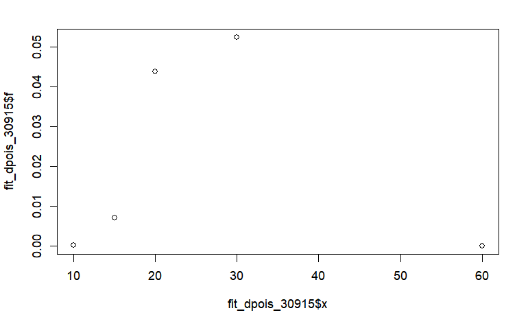

```r
plot(x= fit_dpois_30915$x, y=fit_dpois_30915$f)
```

```r
#Calculating normal distribution
norm_c309_2015_ <- fitdistrplus::fitdist(data=c_309_2015$DURATION%>% unlist() %>% as.numeric(), "norm", method="mle", optim.method="Nelder-Mead", weights = round(c_309_2015$WGHT_EPI))
summary(norm_c309_2015_)
```

```
Fitting of the distribution ' norm ' by maximum likelihood
Parameters :
```

|  | estimate | Std. Error |
| --- | --- | --- |
| mean | 25.78178 | 0.14091905 |
| sd | 17.48419 | 0.09967165 |

```
Loglikelihood:  -65887.18   AIC:  131778.4   BIC:  131779
Correlation matrix:
              mean            sd
mean  1.0000000000 -0.0003693854
sd   -0.0003693854  1.0000000000
```

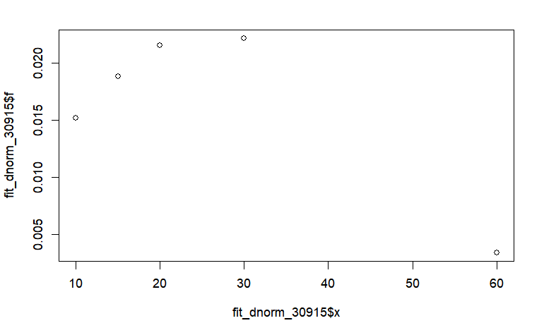

```r
fit_dnorm_30915 <- data.frame(f = dnorm(c_309_2015$DURATION, mean = norm_c309_2015_$estimate[1], sd = norm_c309_2015_$estimate[2]), x = c_309_2015$DURATION, type = "norm")

plot(x= fit_dnorm_30915$x, y=fit_dnorm_30915$f)
```

```r
#Calculating exponential distribution
exp_c309_2015_ <- fitdistrplus::fitdist(data=c_309_2015$DURATION%>% unlist() %>% as.numeric(), "exp", method="mle", optim.method="Nelder-Mead", weights = round(c_309_2015$WGHT_EPI))
summary(exp_c309_2015_)
```

```
Fitting of the distribution ' exp ' by maximum likelihood
Parameters :
```

|  | estimate | Std. Error |
| --- | --- | --- |
| rate | 0.03878472 | 0.0003123891 |

```
Loglikelihood:  -65422.12   AIC:  130846.2   BIC:  130846.5
```

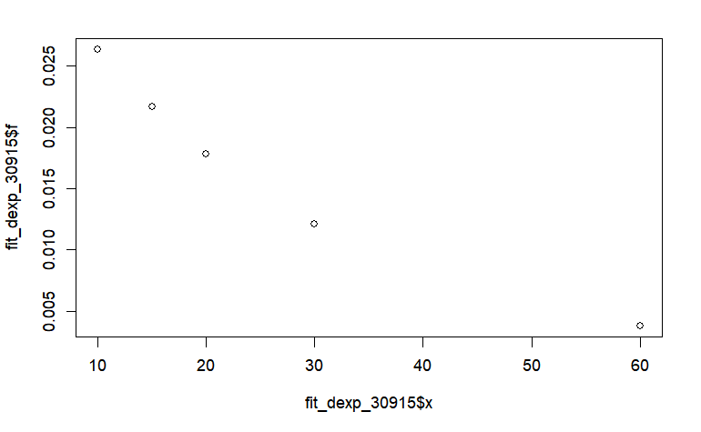

```r
fit_dexp_30915 <- data.frame(f = dexp(c_309_2015$DURATION, rate = exp_c309_2015_$estimate[1]),
                       x = c_309_2015$DURATION, type = "exp")

plot(x = fit_dexp_30915$x, y = fit_dexp_30915$f)
```

Now let’s compare these models AIC and BIC to see which fits the walk data best:

```r
#comparing these models AIC and BIC to see which fits the walk data best:
broom::glance(MASS::fitdistr(w_309_2015$DURATION%>% unlist() %>% as.numeric(),"gamma"))
```

| logLik | AIC | BIC | nobs |
| --- | --- | --- | --- |
| -884.4337 | 1772.867 | 1779.91 | 250 |

```r
broom::glance(MASS::fitdistr(w_309_2015$DURATION%>% unlist() %>% as.numeric(),"normal"))
```

| logLik | AIC | BIC | nobs |
| --- | --- | --- | --- |
| -1007.133 | 2018.267 | 2025.31 | 250 |

```r
broom::glance(MASS::fitdistr(w_309_2015$DURATION%>% unlist() %>% as.numeric(),"poisson"))
```

| logLik | AIC | BIC | nobs |
| --- | --- | --- | --- |
| -1576.023 | 3154.046 | 3157.568 | 250 |

```r
broom::glance(MASS::fitdistr(w_309_2015$DURATION%>% unlist() %>% as.numeric(),"exponential"))
```

| logLik | AIC | BIC | nobs |
| --- | --- | --- | --- |
| -921.2807 | 1844.561 | 1848.083 | 250 |

So, gamma has largest logLik and the smallest AIC and BIC. we will pick gamma function for walking trips in 2015!(309)

```r
cycling_30915_gamma <- gamma_c309_2015_
c_309_2015 <- c_309_2015 %>%
 mutate(f_309 = dgamma(DURATION, cycling_30915_gamma$estimate["shape"], cycling_30915_gamma$estimate["rate"]))
summary(c_309_2015$f_309)
```

```
    Min.  1st Qu.   Median     Mean  3rd Qu.     Max.
0.002822 0.021952 0.027573 0.024623 0.030308 0.030516
```

###Destination : Cycling - Place of worship (310), 2015 using a skew vs. kurtois graph to descriptive statistics of data

```r
# creating a skew vs. kurtois graph for cycling 2015

# Filter the data based on the "destination" column
 c_310_2015 <- cycling_2015 %>%
  filter(destination == "310")
count <- sum(cycling_2015$destination == "310")
print(count)
```

```
[1] 1
```

```r
#descdist(c_310_2015$DURATION %>% unlist() %>% as.numeric(), discrete=FALSE, boot=500)
```

creating a new walking data frame that have all the f values for walking 2015

```r
walking_2015_f <- bind_rows(w_300_2015, w_301_2015, w_302_2015, w_303_2015, w_305_2015, w_306_2015, w_307_2015, w_309_2015, w_310_2015)
```

creating a new cycling data frame that have all the f values for cycling 2015

```r
cycling_2015_f <- bind_rows(c_300_2015, c_301_2015, c_302_2015, c_303_2015, c_305_2015, c_306_2015, c_307_2015, c_309_2015, c_310_2015)
```